# Clustering

```r
rm(list=ls())
tropical=  c('darkorange', 'dodgerblue', 'hotpink', 'limegreen', 'yellow')
palette(tropical)
```

```r
## see ch. 10 Hooks of Xie's knitr book
library(knitr)
knit_hooks$set(setPch = function(before, options, envir) {
  if(before) par(pch = 19)
})
opts_chunk$set(setPch = TRUE)
```

```r
knitr::opts_chunk$set(fig.width=5, fig.height=5, size="footnotesize",
                      warning=FALSE, message=FALSE)
knitr::knit_hooks$set(small.mar = function(before, options, envir) {
  if (before) graphics::par(mar = c(5,5,1.5,1))
})
```

## Genomic Data Science Specialization

Johns Hopkins University

Course 6 : Statistics for Genomic Data Science

Module 1

Clustering in R (9:09)

## Dependencies

This document depends on the following packages:

Dendextend package in order to enhance the visual appeal of dendograms.

```r
  library(devtools)
  library(Biobase)
  library(dendextend)
```

To install these packages you can use the code (or if you are compiling the document, remove the `eval=FALSE` from the chunk.)

```r
install.packages(c("devtools","dendextend"))
source("http://www.bioconductor.org/biocLite.R")
biocLite(c("Biobase"))
```

## General principles

- How do we define close?
- How do we group things?
- How do we visualize the grouping?
- How do we interpret the grouping?

## Load some data

We will use this expression set to look at how we use plots and tables to check for different characteristics

```r
con =url("http://bowtie-bio.sourceforge.net/recount/ExpressionSets/bodymap_eset.RData")
load(file=con)
close(con)
bm = bodymap.eset
pdata=pData(bm)
edata=as.data.frame(exprs(bm))
fdata = fData(bm)
ls()
```

```
## [1] "bm"           "bodymap.eset" "con"          "edata"        "fdata"
## [6] "pdata"        "tropical"
```

## Calculate distances between samples

- Most important step
  - Garbage in -> garbage out
- Distance or similarity
  - Continuous - euclidean distance
  - Continous - correlation similarity
  - Binary - manhattan distance
- Pick a distance/similarity that makes sense for your problem

First we log transform and remove lowly expressed genes, then calculate Euclidean distance

```r
edata = edata[rowMeans(edata) > 5000,]
dim(edata)
```

```
## [1] 1198   19
```

It is necessary to require that the mean count exceed 5000. Consequently, applying this process yields a data set comprising approximately 1,100 or 1,200 genes. The subsequent step is to perform a log2 transformation.

```r
edata = log2(edata + 1)

# By default calculates the distance between rows
dist1 = dist(t(edata))
dist1
```

```
##           ERS025098 ERS025092 ERS025085 ERS025088 ERS025089 ERS025082 ERS025081
## ERS025092  47.83454
## ERS025085  83.96220  77.54223
## ERS025088  52.34542  61.39250  86.94737
## ERS025089  46.68212  46.77265  73.16788  58.31017
## ERS025082  86.75159  80.83051  88.75160  71.99587  79.45885
## ERS025081  71.05994  63.21369  76.65367  77.80793  60.62444  89.12446
## ERS025096 103.83113 102.17843 105.85568 112.79204 103.45186 116.60888  88.02845
## ERS025099  57.02675  50.93496  86.40210  68.68676  53.76118  88.76296  66.06906
## ERS025086  51.75235  39.17648  80.98108  54.08224  48.90812  74.52476  67.95134
## ERS025084  99.71989  97.27087 111.50972  87.44926  95.20849  97.83349  92.97540
## ERS025087 117.34448 115.63130 133.79183 104.16750 113.03830 118.52652 112.89021
## ERS025093 112.33075 110.15115 128.04004  98.37916 107.32375 110.80959 107.59375
## ERS025083  57.81901  48.50112  73.38989  64.35612  47.07506  80.53871  59.79530
## ERS025095  58.80015  54.58770  82.38348  65.18464  45.91571  85.73765  62.64854
## ERS025097  95.16362  92.35075  98.79747  75.04964  89.42727  67.22592 101.20114
## ERS025094  67.78771  59.91701  82.01750  57.73635  58.75552  73.77785  67.51924
## ERS025090  78.50388  72.70717  90.64349  56.51921  70.55099  70.21842  76.38506
## ERS025091 124.49703 115.97526 117.59068 133.96367 127.93296 137.30302 123.90636
##           ERS025096 ERS025099 ERS025086 ERS025084 ERS025087 ERS025093 ERS025083
## ERS025092
## ERS025085
## ERS025088
## ERS025089
## ERS025082
## ERS025081
## ERS025096
## ERS025099 103.83183
## ERS025086 103.76689  45.92130
## ERS025084 122.73463  96.74240  86.12869
## ERS025087 146.58517 112.56898 104.07750  45.59098
## ERS025093 138.62242 107.82539  98.48691  40.54726  16.67730
## ERS025083 103.15733  53.74561  50.23602  94.26817 111.37489 107.05659
## ERS025095 113.95025  54.95038  52.86539  91.02333 105.29379 101.42571  48.54519
## ERS025097 127.23273 101.10251  85.70968 108.33214 126.80170 120.05209  91.94681
## ERS025094 111.78740  69.97030  57.69175  69.20467  86.04195  80.51045  54.29446
## ERS025090 120.04394  80.59999  64.70507  76.69203  90.98039  85.86444  67.00176
## ERS025091 132.80823 119.52176 116.71838 153.93360 173.34058 168.83314 119.05197
##           ERS025095 ERS025097 ERS025094 ERS025090
## ERS025092
## ERS025085
## ERS025088
## ERS025089
## ERS025082
## ERS025081
## ERS025096
## ERS025099
## ERS025086
## ERS025084
## ERS025087
## ERS025093
## ERS025083
## ERS025095
## ERS025097  94.59446
## ERS025094  61.11209  83.09611
## ERS025090  71.25648  69.01914  54.13557
## ERS025091 130.16308 140.39229 132.76351 138.47040
```

The distances between the samples can be observed, as illustrated by the diagonal line, which represents the distance between a sample and itself. It is evident that the distance in question is minimal. It is evident that some samples are in closer proximity to one another, as illustrated by the white clusters. Conversely, other samples exhibit greater distances between them, as exemplified by the 19th, 18th, and 19th samples, which are relatively distant from one another. This is indicated by the blue distances.

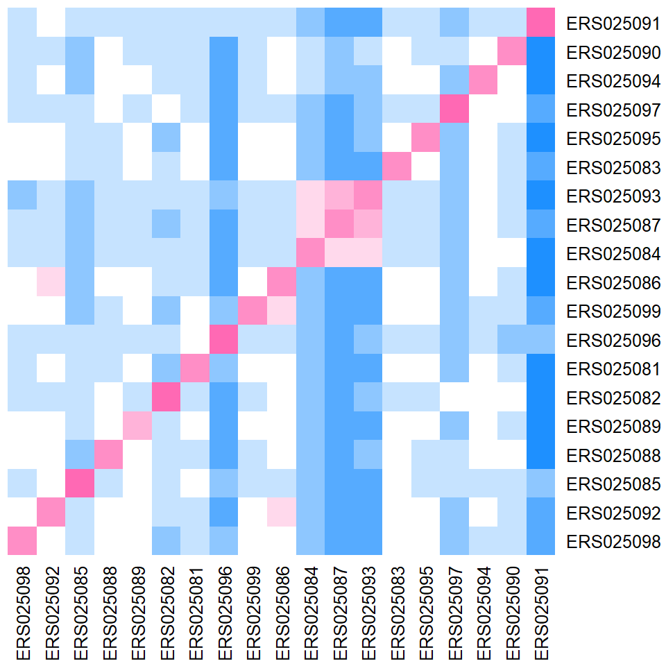

```r
## Look at distance matrix
colramp = colorRampPalette(c(3,"white",2))(9)
heatmap(as.matrix(dist1),col=colramp,Colv=NA,Rowv=NA)
```

Subsequently, clustering can be performed on this data set. The H-clust function is employed for hierarchical clustering.

## Now cluster the samples

Here we use the distance we previously calculated to perform a hierarchical clustering and plot the dendrogram:

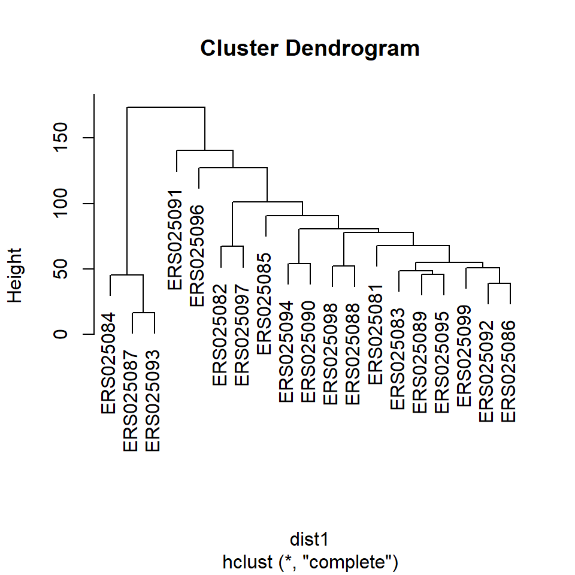

```r
hclust1 = hclust(dist1)
plot(hclust1)
```

We can also force all of the leaves to terminate at the same spot

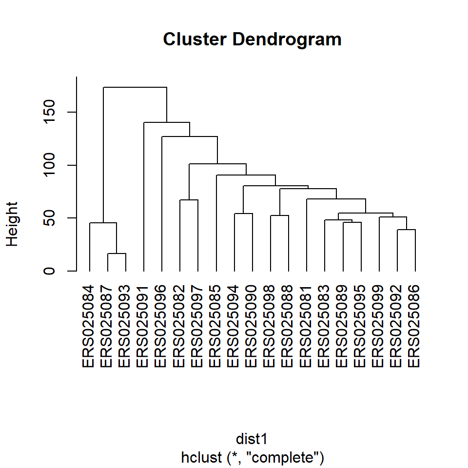

```r
plot(hclust1,hang=-1)
```

We can also color the dendrogram either into a fixed number of groups

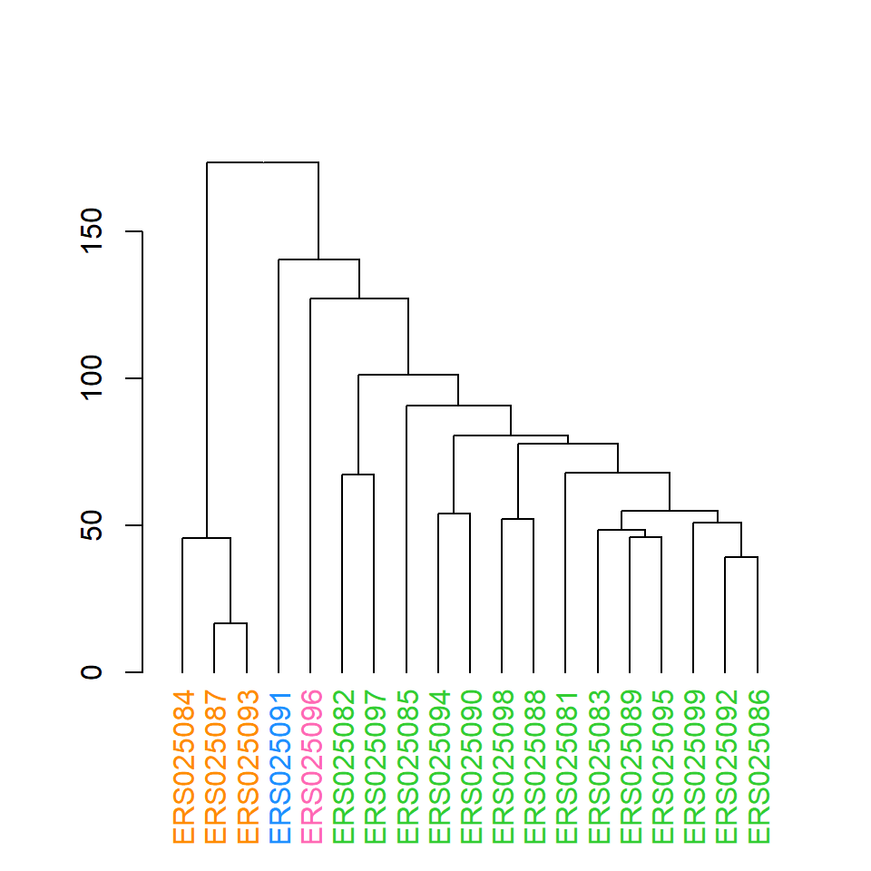

```r
dend = as.dendrogram(hclust1)
dend = color_labels(hclust1,4,col=1:4)
plot(dend)
```

The number of clusters can be specified. To view three clusters, the number of clusters and colours may be modified and a plot generated.

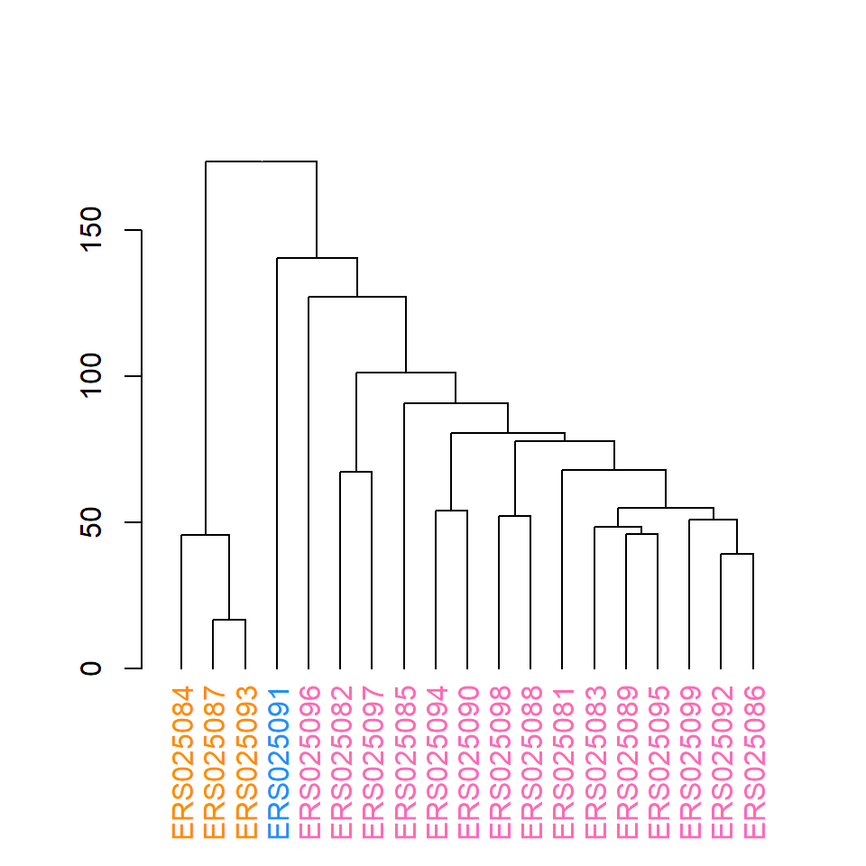

```r
dend = color_labels(hclust1,3,col=1:3)
plot(dend)
```

### Or you can color them directly

The initial ten samples come from one case, the subsequent nine from another. Labels can be defined directly, with the first ten samples labelled ‘one’ and the subsequent nine ‘two’. Samples can then be plotted according to their labels, as illustrated. This allows for the clear visual separation of the two groups.

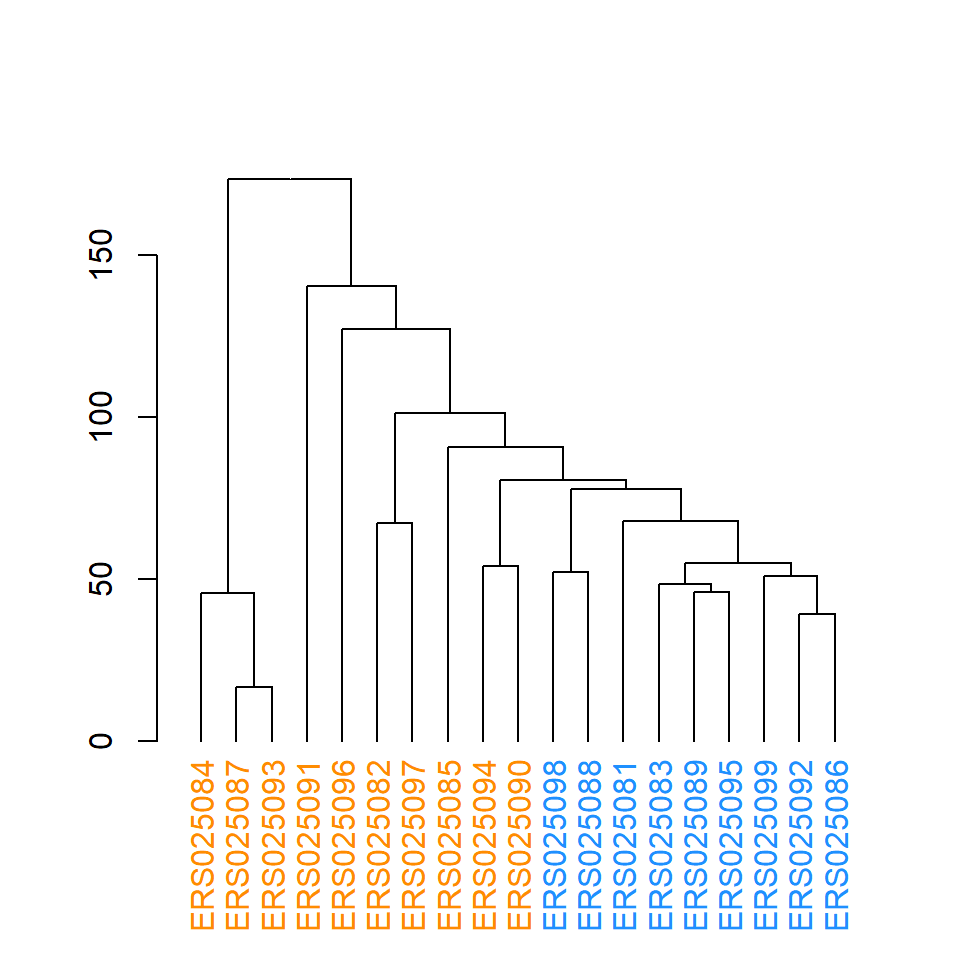

```r
labels_colors(dend) = c(rep(1,10),rep(2,9))
plot(dend)
```

This can get very fancy and we won’t cover all the options here but for further ideas check out the [dendextend package](http://htmlpreview.github.io/?https://github.com/talgalili/dendextend/blob/master/inst/ignored/Introduction%20to%20dendextend.html).

## K-means clustering

Now we can perform k-means clustering. By default, the rows are clustered. You can either input the cluster means (often unknown) or the number of clusters (here I input 3 clusters)

```r
kmeans1 = kmeans(edata,centers=3)
names(kmeans1)
```

```
## [1] "cluster"      "centers"      "totss"        "withinss"     "tot.withinss"
## [6] "betweenss"    "size"         "iter"         "ifault"
```

### Now we can look at the cluster centers

The data set comprises three distinct cluster centres. The middle samples exhibit a considerably higher value than the other samples, indicating a prominent cluster comprising these points. Three distinct cluster centres were identified and each gene was assigned to the most closely associated centre.

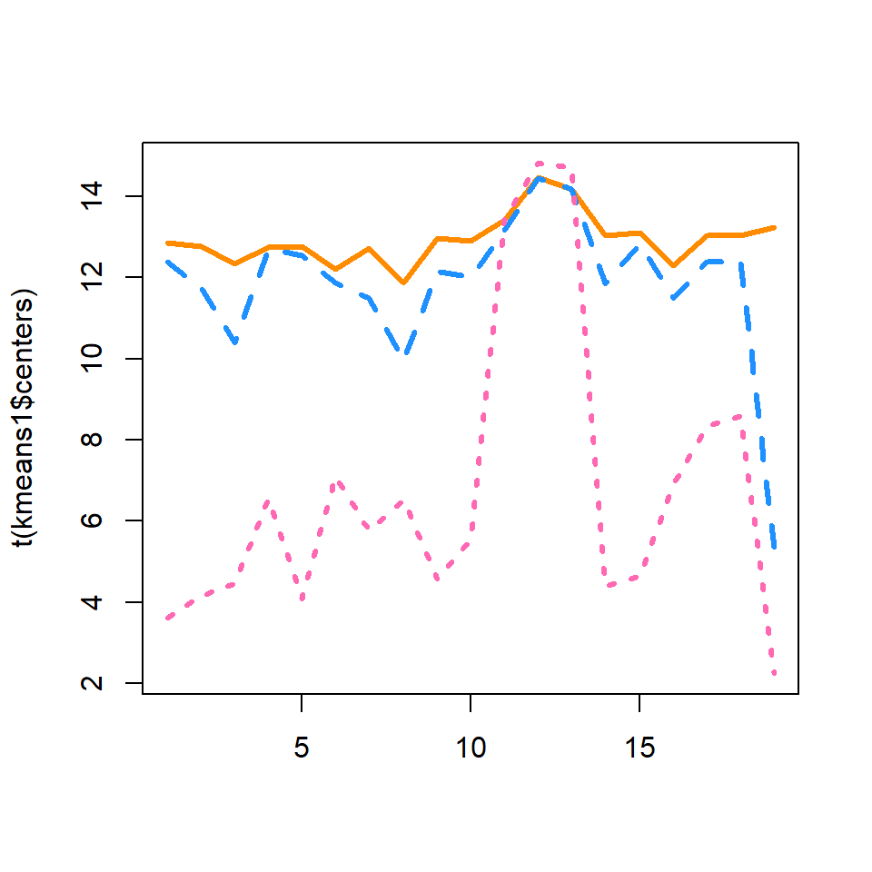

```r
matplot(t(kmeans1$centers),col=1:3,type="l",lwd=3)
```

### We can also look at how many belong to each cluster

```r
table(kmeans1$cluster)
```

```
##
##   1   2   3
## 969 169  60
```

```r
kmeans1$cluster[1:10]
```

```
## ENSG00000001561 ENSG00000003056 ENSG00000004478 ENSG00000004776 ENSG00000004779
##               1               1               1               2               1
## ENSG00000004897 ENSG00000005007 ENSG00000005339 ENSG00000006007 ENSG00000006125
##               1               1               1               1               1
```

### And cluster the data together and plot

A clustered version will be created using the k-mean clustering method. Genes with similar characteristics have been grouped together.

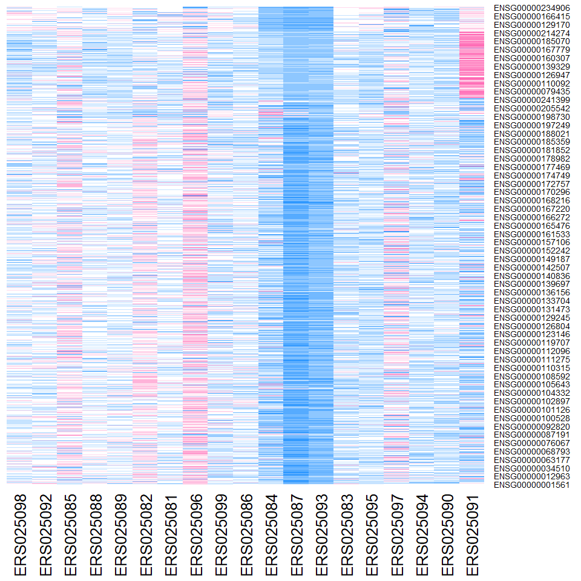

```r
heatmap(as.matrix(edata)[order(kmeans1$cluster),],col=colramp,Colv=NA,Rowv=NA)
```

Note that this is a random start so you get a different clustering if you run it again you get a different answer

```r
kmeans2 = kmeans(edata,centers=3)
table(kmeans1$cluster,kmeans2$cluster)
```

```
##
##       1   2   3
##   1   0 381 588
##   2   3  15 151
##   3  60   0   0
```

It is also useful to compile the time the document was processed. This document was processed on: 2024-10-16.